# Retoño de la higuera tras poda por infestación de eburia

2026-09-18

Desde que tengo memoria, de vez en cuando un insecto devoraba la higuera produciendo un rastro de acerrín y agujeros en las ramas que terminaban secandose. Mi madre la combatia con insecticida.

El uso de insecticida era periódico, la plaga nunca desapareció. Ahora sé que los insecticidas causan daño neurológico[^1]. Cuándo volvió a aparecer la plaga hace un par de años empecé a combatirla manualmente, podando las ramas secas y buscando identificar al insecto.

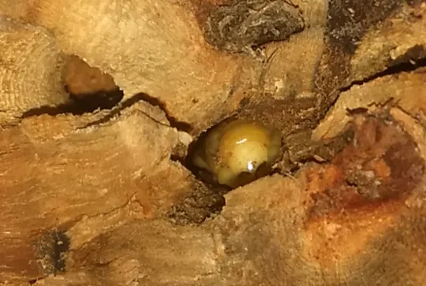

Cámara de anidación de eburia en una higuera

Finalmente identifiqué a la responsable como la larva de la Eburia, un insecto volador de cuernos largos que en mi infancia conocí como “torito”, pase toda la vida viendolo sin saber que él sería el responsable de secarle las ramas a la higuera.

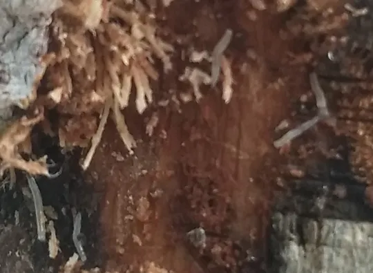

Nido de Eburia

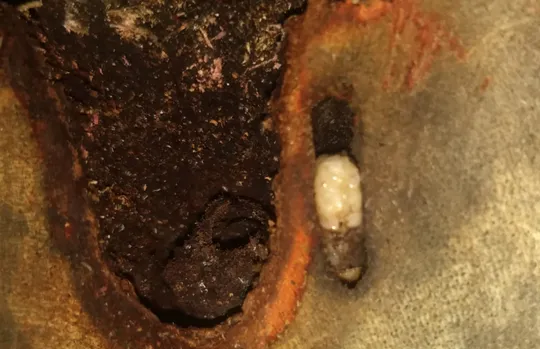

Pupa de eburia mutilada

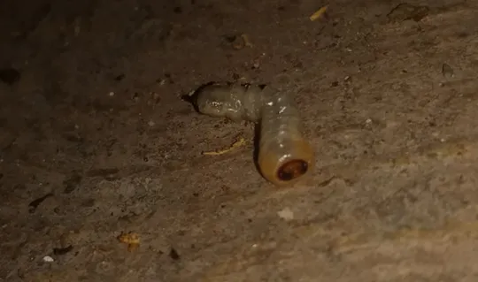

Larva de Eburia, berrenadora de higuera.

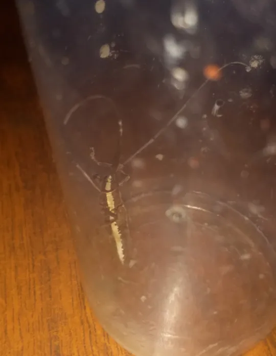

Eburia adulta o torito (lateral)

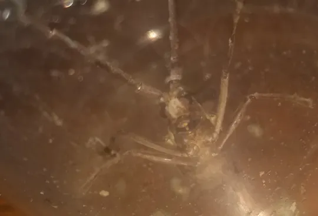

Eburia adulta o torito (frente)

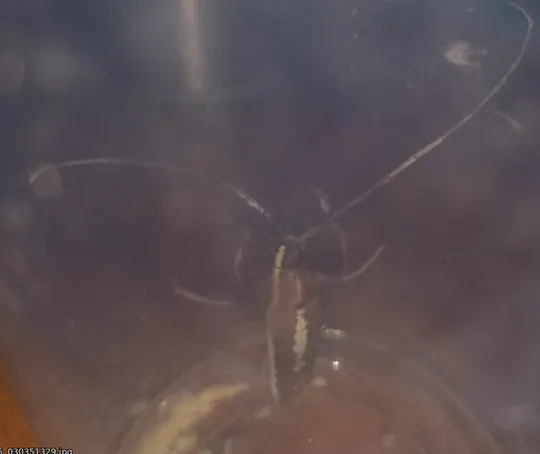

Eburia adulta o torito (espalda)

Pase largas jornada cortando las ramas, tallando el trinco saturando los agujeros con agua, rellenando con acerrín y sellando con cera. Las ramas tratadas iban presentando retoños y en algún momento parecia que le hiba ganando a la plaga, pero luego me di cuenta que el tronco principal estab infestado y que si moria básicamente moriria todo el árbol. Intente lo más que pude hasta que ví las ramas secarse y decidí podarlo. Aún sin haber logrado reproducirlo, empecé rodear el tronco con tierra de composta y acostar las ramas más largasahí, con las esperanza de poder propagar el árbol al menos para evitar que se secara por completo

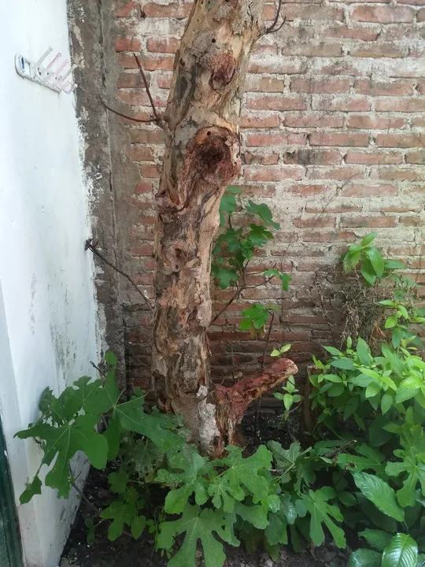

Tronco seco de la higuera

Hace un tiempo que noté raices nuevas y ya tiene algunos nuevos retoños.

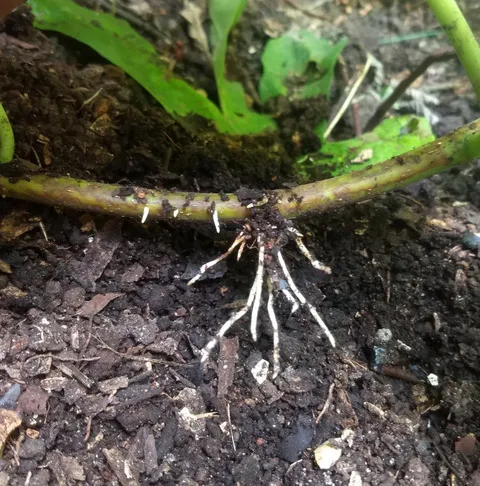

Rama acostada enraizando

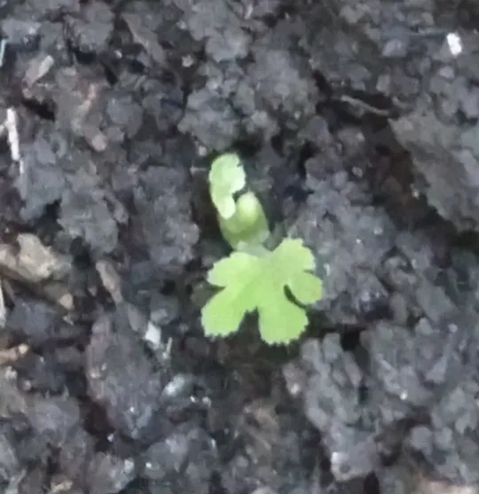

Retoño de higuera esparcida por acodo terrestre

[^1]: Neurotoxicidad de los plaguicidas como agentes disruptores endocrinos: Una revisión. Revista del Instituto Nacional de Higiene Rafael Rangel. INHRR vol.45 no.2 Caracas Dec. 2014. Consultado el 2026-09-19 en [https://ve.scielo.org/](https://ve.scielo.org/scielo.php?script=sci_arttext&pid=S0798-04772014000200007)

[figure not shown]